# AI_CA0

پروژه صفر : آشنایی با هوش مصنوعی

دکتر مرادی

ثمین مهدی زاده 810196623

**مقدمه**

در این پروژه سعی شده است با گرفتن اطلاعات یک دیتاست که حاوی اطلاعات مربوط به 1000 کاربر یک سایت است که با یک آگهی اینترنتی برخورد کرده اند، پیش بینی شود که کاربرانی که اطلاعات مربوط به ستون هدف (Clicked on Ad) آن ها ناقص است روی آگهی کیک کرده اند یا خیر.به این منظور به کمک تحلیل آماری ویژگی های هر کاربر را بررسی کرده و بهترین ویژگی را به عنوان ورودی مدل انتخاب می کنیم.در نهایت نیز برای سطر هایی که مقدار ستون هدف آنها خالی است کلاس متناسب (کلیک یا عدم کلیک) پیش بینی شده است و به همراه اندیس در فایل result.csv ذخیره شده است.

جهت تحلیل اطلاعات با سرعت بالا از vectorization استفاده شده است که باعث می شود محاسبات مربوط به داده ها به صورت همزمان انجام شود.

**شرح پروژه**

در ابتدا به کمک دستور read_csv فایل مربوط به دیتاست به منظور تحلیل داده ها لود شده است.همچنین کتاب خانه های مورد نیاز جهت انجام پروژه اضافه شده اند.

```python
import pandas as pd
import numpy as np
import scipy.stats
import matplotlib.pyplot as plt
import time
data = pd.read_csv('advertising_dataset.csv')
```

توابع head وtail به ما این امکان را می دهند که نمونه ای از داده خود را ببینیم head اول داده ها و tail آخر داده ها را نمایش می دهد. تعداد پیش فرض نمایش داده ها برابر5 است اما می توانیم با دادن عدد مورد نظر به عنوان آرگومان ورودی این توابع، تعداد دلخواه نمونه ها را مشاهده کنیم.

```python
data.head()
```

|  | Unnamed: 0 | Daily Time Spent on Site | Age | Area Income | Daily Internet Usage | Ad Topic Line | City | Gender | Country | Timestamp | Clicked on Ad |
| --- | --- | --- | --- | --- | --- | --- | --- | --- | --- | --- | --- |
| 0 | 0 | 68.95 | 35.0 | 61833.90 | 256.09 | Cloned 5thgeneration orchestration | Wrightburgh | Female | Tunisia | 2016-03-27 00:53:11 | 0.0 |
| 1 | 1 | 80.23 | 31.0 | 68441.85 | NaN | Monitored national standardization | West Jodi | Male | Nauru | 2016-04-04 01:39:02 | 0.0 |
| 2 | 2 | 69.47 | 26.0 | 59785.94 | 236.50 | Organic bottom-line service-desk | Davidton | Female | San Marino | 2016-03-13 20:35:42 | 0.0 |
| 3 | 3 | 74.15 | 29.0 | 54806.18 | 245.89 | Triple-buffered reciprocal time-frame | West Terrifurt | Male | Italy | 2016-01-10 02:31:19 | 0.0 |
| 4 | 4 | 68.37 | 35.0 | 73889.99 | 225.58 | Robust logistical utilization | South Manuel | Female | Iceland | 2016-06-03 03:36:18 | 0.0 |

```python
data.tail()
```

|  | Unnamed: 0 | Daily Time Spent on Site | Age | Area Income | Daily Internet Usage | Ad Topic Line | City | Gender | Country | Timestamp | Clicked on Ad |
| --- | --- | --- | --- | --- | --- | --- | --- | --- | --- | --- | --- |
| 995 | 995 | 72.97 | 30.0 | 71384.57 | 208.58 | Fundamental modular algorithm | Duffystad | Male | Lebanon | 2016-02-11 21:49:00 | 1.0 |
| 996 | 996 | 51.30 | 45.0 | 67782.17 | 134.42 | Grass-roots cohesive monitoring | New Darlene | Male | Bosnia and Herzegovina | 2016-04-22 02:07:01 | 1.0 |
| 997 | 997 | 51.63 | 51.0 | 42415.72 | 120.37 | Expanded intangible solution | South Jessica | Male | Mongolia | 2016-02-01 17:24:57 | 1.0 |
| 998 | 998 | 55.55 | 19.0 | 41920.79 | 187.95 | Proactive bandwidth-monitored policy | West Steven | Female | Guatemala | 2016-03-24 02:35:54 | 0.0 |
| 999 | 999 | NaN | 26.0 | 29875.80 | 178.35 | Virtual 5thgeneration emulation | Ronniemouth | Female | Brazil | 2016-06-03 21:43:21 | 1.0 |

تابع describe خلاصه ای از اطلاعات عددی داده مانند تعداد داده های دارای مقدار،میانگین،انحراف معیارو... را به ازای هر ویژگی نشان می دهد.

```python
data.describe()
```

|  | Unnamed: 0 | Daily Time Spent on Site | Age | Area Income | Daily Internet Usage | Clicked on Ad |
| --- | --- | --- | --- | --- | --- | --- |
| count | 1000.000000 | 907.000000 | 979.000000 | 1000.000000 | 913.000000 | 832.000000 |
| mean | 499.500000 | 64.794818 | 36.009193 | 55000.000080 | 179.751271 | 0.496394 |
| std | 288.819436 | 15.954841 | 8.783636 | 13414.634022 | 43.957934 | 0.500288 |
| min | 0.000000 | 32.600000 | 19.000000 | 13996.500000 | 104.780000 | 0.000000 |
| 25% | 249.750000 | 50.615000 | 29.000000 | 47031.802500 | 138.550000 | 0.000000 |
| 50% | 499.500000 | 67.940000 | 35.000000 | 57012.300000 | 183.480000 | 0.000000 |
| 75% | 749.250000 | 78.555000 | 42.000000 | 65470.635000 | 217.850000 | 1.000000 |
| max | 999.000000 | 91.430000 | 61.000000 | 79484.800000 | 269.960000 | 1.000000 |

در ادامه به کمک دستور info اطلاعاتی راجع به نوع هر ستون،تعداد سطرهایی از هر ستون که خالی نیستند و... را مشاهده می کنیم.

```python
data.info()
```

```
<class 'pandas.core.frame.DataFrame'>
RangeIndex: 1000 entries, 0 to 999
Data columns (total 11 columns):
 #   Column                    Non-Null Count  Dtype
---  ------                    --------------  -----
 0   Unnamed: 0                1000 non-null   int64
 1   Daily Time Spent on Site  907 non-null    float64
 2   Age                       979 non-null    float64
 3   Area Income               1000 non-null   float64
 4   Daily Internet Usage      913 non-null    float64
 5   Ad Topic Line             1000 non-null   object
 6   City                      1000 non-null   object
 7   Gender                    1000 non-null   object
 8   Country                   1000 non-null   object
 9   Timestamp                 1000 non-null   object
 10  Clicked on Ad             832 non-null    float64
dtypes: float64(5), int64(1), object(5)
memory usage: 86.1+ KB
```

همان طور که دیده می شود بعضی ستون ها عددی نیستند و برای پردازش آن ها لازم است از برچسب گذاری(برای مثال اختصاص عدد به هر دسته)استفاده کنیم. به این منظور ستون Gender که حاوی اطلاعات مربوط به جنسیت کاربران است را این گونه تغییر می دهیم که درصورتی که کاربر مرد بود عدد 1 و در غیر این صورت عدد 0 جایگزین شود.

```python
data['Gender'] = np.where(data.Gender =='Male',1,0)
data
```

|  | Unnamed: 0 | Daily Time Spent on Site | Age | Area Income | Daily Internet Usage | Ad Topic Line | City | Gender | Country | Timestamp | Clicked on Ad |
| --- | --- | --- | --- | --- | --- | --- | --- | --- | --- | --- | --- |
| 0 | 0 | 68.95 | 35.0 | 61833.90 | 256.09 | Cloned 5thgeneration orchestration | Wrightburgh | 0 | Tunisia | 2016-03-27 00:53:11 | 0.0 |
| 1 | 1 | 80.23 | 31.0 | 68441.85 | NaN | Monitored national standardization | West Jodi | 1 | Nauru | 2016-04-04 01:39:02 | 0.0 |
| 2 | 2 | 69.47 | 26.0 | 59785.94 | 236.50 | Organic bottom-line service-desk | Davidton | 0 | San Marino | 2016-03-13 20:35:42 | 0.0 |
| 3 | 3 | 74.15 | 29.0 | 54806.18 | 245.89 | Triple-buffered reciprocal time-frame | West Terrifurt | 1 | Italy | 2016-01-10 02:31:19 | 0.0 |
| 4 | 4 | 68.37 | 35.0 | 73889.99 | 225.58 | Robust logistical utilization | South Manuel | 0 | Iceland | 2016-06-03 03:36:18 | 0.0 |
| ... | ... | ... | ... | ... | ... | ... | ... | ... | ... | ... | ... |
| 995 | 995 | 72.97 | 30.0 | 71384.57 | 208.58 | Fundamental modular algorithm | Duffystad | 1 | Lebanon | 2016-02-11 21:49:00 | 1.0 |
| 996 | 996 | 51.30 | 45.0 | 67782.17 | 134.42 | Grass-roots cohesive monitoring | New Darlene | 1 | Bosnia and Herzegovina | 2016-04-22 02:07:01 | 1.0 |
| 997 | 997 | 51.63 | 51.0 | 42415.72 | 120.37 | Expanded intangible solution | South Jessica | 1 | Mongolia | 2016-02-01 17:24:57 | 1.0 |
| 998 | 998 | 55.55 | 19.0 | 41920.79 | 187.95 | Proactive bandwidth-monitored policy | West Steven | 0 | Guatemala | 2016-03-24 02:35:54 | 0.0 |
| 999 | 999 | NaN | 26.0 | 29875.80 | 178.35 | Virtual 5thgeneration emulation | Ronniemouth | 0 | Brazil | 2016-06-03 21:43:21 | 1.0 |

1000 rows × 11 columns

به کمک دستور زیر می توان مشاهده کرد که چه تعداد از داده های موجود در هر ستون خالی هستند.

```python
data.isna().sum()
```

```
Unnamed: 0                    0
Daily Time Spent on Site     93
Age                          21
Area Income                   0
Daily Internet Usage         87
Ad Topic Line                 0
City                          0
Gender                        0
Country                       0
Timestamp                     0
Clicked on Ad               168
dtype: int64
```

برای پر کردن داده های خالی روش های گوناگونی وجود دارد.یکی از این روش ها که در همین پروژه نیز از آن استفاده شده است جایگذاری میانگین هر ستون در سلول های خالی است.روش دیگر استفاده از میانه هر ستون است.باتوجه به نوع داده ای که به ما داده می شود ممکن است یکی از این روش ها بهتر عمل کند.برای مثال در صورتی که همه داده ها در رنج تقریبا یکسانی قرار داشته باشند و داده ی پرتی نداشته باشیم،استفاده از میانگین روش خوبی است چرا که در این صورت میانگین هر ستون می تواند نماینده ی خوبی برای داده های آن ستون باشد همچنین لازم نیست هزینه ای برای سورت داده ها بدهیم تا میانه را به دست آوریم در غیر این صورت ممکن است داده ای وجود داشته باشد که باعث شود میانگین کلی داده خیلی پایین یا خیلی بالا برود و باعث شود میانگین تخمین خیلی خوبی برای داده های خالی نباشد.در این صورت استفاده از میانه راه بهتری است چرا که داده ها سورت می شوند و داده ی میانی برای قسمت های خالی در نظر گرفته می شود.در این صورت نقش داده های پرت کم می شود.  
یکی دیگر از روش ها،دسته بندی داده ها بسته براساس ویژگی های آن هاست یعنی براساس یک سری ویژگی داده ها را دسته بندی کنیم تا داده های شبیه به هم در یک دسته قرار گیرند و برای هر سلول خالی میانگین دسته اش را جاگذاری کنیم نه میانگین کل داده ها.اگرچه این روش نسبت به میانگین هزینه ی بیشتری دارد ولی ممکن است درجاهایی که احتیاج به خطای کمتری داریم این راه بهتر عمل کند و داده های از رست رفته را با دقت بیشتری بازیابی کند.

```python
col = list(data)
col.remove('Clicked on Ad')
data[col] = data[col].fillna(value=data[col].mean())
data.head()
```

|  | Unnamed: 0 | Daily Time Spent on Site | Age | Area Income | Daily Internet Usage | Ad Topic Line | City | Gender | Country | Timestamp | Clicked on Ad |
| --- | --- | --- | --- | --- | --- | --- | --- | --- | --- | --- | --- |
| 0 | 0 | 68.95 | 35.0 | 61833.90 | 256.090000 | Cloned 5thgeneration orchestration | Wrightburgh | 0 | Tunisia | 2016-03-27 00:53:11 | 0.0 |
| 1 | 1 | 80.23 | 31.0 | 68441.85 | 179.751271 | Monitored national standardization | West Jodi | 1 | Nauru | 2016-04-04 01:39:02 | 0.0 |
| 2 | 2 | 69.47 | 26.0 | 59785.94 | 236.500000 | Organic bottom-line service-desk | Davidton | 0 | San Marino | 2016-03-13 20:35:42 | 0.0 |
| 3 | 3 | 74.15 | 29.0 | 54806.18 | 245.890000 | Triple-buffered reciprocal time-frame | West Terrifurt | 1 | Italy | 2016-01-10 02:31:19 | 0.0 |
| 4 | 4 | 68.37 | 35.0 | 73889.99 | 225.580000 | Robust logistical utilization | South Manuel | 0 | Iceland | 2016-06-03 03:36:18 | 0.0 |

با گذاشتن شرط های مختلف بر روی داده می توان اطلاعات گوناگونی از آن استخراج کرد.در ادامه اطلاعاتی مانند تعداد کاربران زن و مرد،تعداد کاربرانی که روی آگهی کلیک کرده اند یا نکرده اند و تعداد کاربرانی که زن هستند و سن بیشتر از 21 سال دارند آمده است.

```python
genderCount = data['Gender'].value_counts()
print("Female: ",genderCount[0],"\nMale: ",genderCount[1])
```

```
Female:  519
Male:  481
```

```python
clickedCount = data['Clicked on Ad'].value_counts()
print("Has clicked: ",clickedCount[1],"\nHas not clicked: ",clickedCount[0])
```

```
Has clicked:  413
Has not clicked:  419
```

```python
size = len(data[(data['Gender']==0) & (data['Age']>21)])
print("Genger = Female & Age > 21 : ",size)
```

```
Genger = Female & Age > 21 :  514
```

همان طور که پیش تر گفته شد استفاده از vectorization باعث می شود سرعت انجام محاسبات بالاتر برود.در ادامه یک بار به کمک این روش و بار دیگر با استفاده از حلقه، میانگین سن کاربرانی که روی آگهی کلیک کرده اند و کاربرانی که روی آگهی کلیک نکرده اند به دست آمده و زمان مربوط به هر یک گزارش شده است.

```python
tic = time.time()
avgAge = data.groupby('Clicked on Ad')['Age'].mean()
toc = time.time()
print("time: ",toc-tic)
avgAge
```

```
time:  0.002131938934326172
```

```
Clicked on Ad
0.0    31.723326
1.0    40.295600
Name: Age, dtype: float64
```

```python
tic = time.time()
clickedAvg,clickedCount = 0,0
notClickedAvg,notClickedCount = 0,0
for i in range(0,len(data)):
    if(data.at[i,'Clicked on Ad']==1):
        clickedAvg += data.at[i,'Age']
        clickedCount +=1
    elif(data.at[i,'Clicked on Ad']==0):
        notClickedAvg += data.at[i,'Age']
        notClickedCount +=1

clickedAvg = clickedAvg/clickedCount
notClickedAvg = notClickedAvg/notClickedCount
toc = time.time()
print("time: ",toc-tic)
print("Clicked avg: ",clickedAvg,"\nNot clicked avg: ",notClickedAvg)
```

```
time:  0.020416975021362305
Clicked avg:  40.295599848637366
Not clicked avg:  31.723325881701896
```

همان طور که مشاهده می شود روش vectorization تقریبا ده برابر سریع تر عمل می کند.

شکل زیر هیستوگرام مربوط به ستون های عددی است که شکل توزیع هر ستون را نشان میدهد.

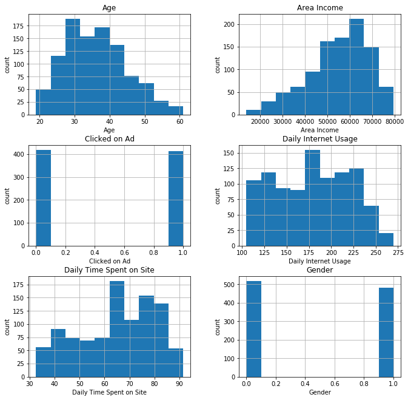

```python
ax = data.drop(columns=['Unnamed: 0']).hist(figsize=(11,11))
for ax in ax.flatten():
    ax.set_xlabel(ax.get_title())
    ax.set_ylabel('count')
```

در ادامه تنها از ستون هایی استفاده شده است که مقدار آن ها عددی است.بنابراین ستون های غیر عددی و ستون Gender دیگر در تحلیل داده ها نقشی ندارند.یکی از راه های بهبود داده ها برای مدل های یادگیری ماشین، نرمال سازی داده هاست.در این پروژه نرمال سازی برای هر ستون ویژگی،با کم کردن میانگین و تقسیم کردن بر انحراف معیار انجام شده است و داده نرمالایز شده در normalized_data ذخیره شده است.

```python
normalized_data = data.select_dtypes([np.number]).drop(columns=['Gender'])
col = list(normalized_data.columns)
col.remove('Unnamed: 0')
col.remove('Clicked on Ad')
normalized_data[col] = (data[col]-data[col].mean())/data[col].std()
normalized_data.head(20)
```

|  | Unnamed: 0 | Daily Time Spent on Site | Age | Area Income | Daily Internet Usage | Clicked on Ad |
| --- | --- | --- | --- | --- | --- | --- |
| 0 | 0 | 0.273474 | -1.161217e-01 | 0.509436 | 1.817578 | 0.0 |
| 1 | 1 | 1.015870 | -5.763771e-01 | 1.002029 | 0.000000 | 0.0 |
| 2 | 2 | 0.307698 | -1.151696e+00 | 0.356770 | 1.351152 | 0.0 |
| 3 | 3 | 0.615713 | -8.065049e-01 | -0.014448 | 1.574722 | 0.0 |
| 4 | 4 | 0.235301 | -1.161217e-01 | 1.408163 | 1.091154 | 0.0 |
| 5 | 5 | -0.316230 | -1.496888e+00 | 0.354953 | 1.118772 | 0.0 |
| 6 | 6 | 1.587145 | -3.462494e-01 | -0.085515 | 0.681156 | 0.0 |
| 7 | 7 | 0.079319 | 1.379709e+00 | -2.266679 | -1.142642 | 1.0 |
| 8 | 8 | 0.640723 | -6.914410e-01 | 1.033349 | 0.994249 | 0.0 |
| 9 | 9 | 0.334682 | -1.842080e+00 | 0.047882 | 0.096874 | 0.0 |
| 10 | 10 | -1.129048 | 1.494773e+00 | -0.698304 | -1.374546 | NaN |
| 11 | 11 | 1.202785 | 1.140061e-01 | 0.558421 | 0.000000 | 0.0 |
| 12 | 12 | 0.000000 | 1.379709e+00 | -0.250702 | -1.586449 | 1.0 |
| 13 | 13 | 0.969141 | -1.635156e-15 | -0.243046 | 0.820917 | 0.0 |
| 14 | 14 | -1.437721 | -3.462494e-01 | -1.790880 | -0.861692 | NaN |
| 15 | 15 | -0.088509 | -1.496888e+00 | -0.210052 | -0.931215 | NaN |
| 16 | 16 | -0.618980 | 1.140061e-01 | -2.315616 | -1.198594 | 1.0 |
| 17 | 17 | 1.134337 | 5.742616e-01 | 1.230826 | 0.185207 | 0.0 |
| 18 | 18 | -0.664392 | -1.057788e-03 | -1.782565 | -1.460974 | 1.0 |
| 19 | 19 | 0.644014 | 4.591977e-01 | -2.324199 | -1.053357 | 1.0 |

به کمک توابع mean و std برای هر دو حالتی که کاربر روی آگهی کلیک کرده و روی آگهی کلیک نکرده میانگین و انحراف معیار هر کدام از ویژگی ها به دست آمده و به کمک scipy.stats.norm.pdf تابع چگالی احتمال مربوط به هر ویژگی رسم شده است.

```python
mean = normalized_data.groupby('Clicked on Ad')[col].mean()
std = normalized_data.groupby('Clicked on Ad')[col].std()
```

```python
mean
```

| Clicked on Ad | Daily Time Spent on Site | Age | Area Income | Daily Internet Usage |
| --- | --- | --- | --- | --- |
| 0.0 | 0.714104 | -0.493148 | 0.476367 | 0.764216 |
| 1.0 | -0.691783 | 0.493211 | -0.498632 | -0.753395 |

```python
std
```

| Clicked on Ad | Daily Time Spent on Site | Age | Area Income | Daily Internet Usage |
| --- | --- | --- | --- | --- |
| 0.0 | 0.531369 | 0.706315 | 0.670476 | 0.592058 |
| 1.0 | 0.836161 | 1.019268 | 1.046199 | 0.723959 |

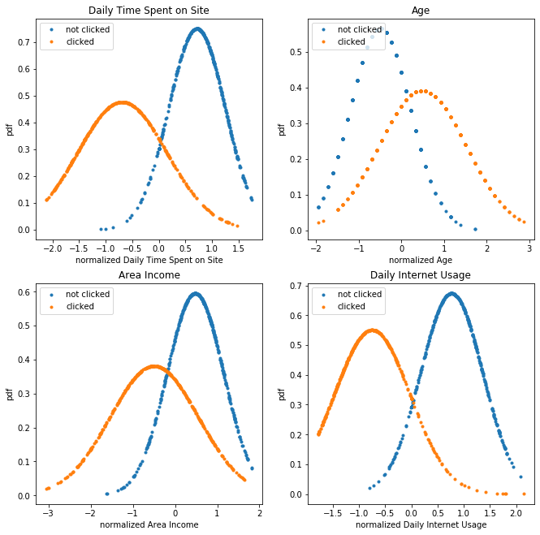

```python
fig,axs = plt.subplots(2,2,figsize=(11,11))
clickedRow = normalized_data.loc[normalized_data['Clicked on Ad']==1]
unclickedRow = normalized_data.loc[normalized_data['Clicked on Ad']==0]
for i,element in enumerate(col):
    x0 = unclickedRow[element]
    x1 = clickedRow[element]
    idx = [i//2,i%2]
    axs[idx[0],idx[1]].plot(x0,scipy.stats.norm.pdf(x0,mean[element][0],std[element][0]),'.',label= 'not clicked')
    axs[idx[0],idx[1]].plot(x1,scipy.stats.norm.pdf(x1,mean[element][1],std[element][1]),'.',label = 'clicked')
    axs[idx[0],idx[1]].set_title(element)
    axs[idx[0],idx[1]].set_xlabel('normalized '+element)
    axs[idx[0],idx[1]].set_ylabel('pdf')
    axs[idx[0],idx[1]].legend(loc="upper left")
```

برای انتخاب بهترین ویژگی باید نموداری را انتخاب کنیم که دو کلاس کلیک کرده و کلیک نکرده را بهتر تفکیک کرده باشد.به این منظور باید نموداری انتخاب شود که مساحت مشترک بین دو نمودار کمینه باشد تا احتمال خطا کمتر شود چرا که در این ناحیه داده ممکن است مربوط به کلاس کلیک نکرده یا کلیک کرده باشد.از شکل واضح است که دو نمودار مربوط به Age وAge Income مساحت مشترک بیشتری دارند.برای بررسی دقیق تر دو نمودار دیگر آن ها را روی هم می کشیم تا تصمیم گیری دقیق تری داشته باشیم.

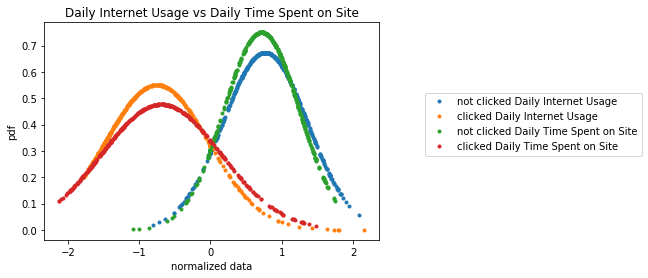

```python
list_comp = ['Daily Internet Usage','Daily Time Spent on Site']
for element in list_comp:
    x0 = unclickedRow[element]
    x1 = clickedRow[element]
    plt.plot(x0,scipy.stats.norm.pdf(x0,mean[element][0],std[element][0]),'.',label= 'not clicked '+element)
    plt.plot(x1,scipy.stats.norm.pdf(x1,mean[element][1],std[element][1]),'.',label = 'clicked '+element)

plt.title('Daily Internet Usage vs Daily Time Spent on Site')
plt.xlabel('normalized data')
plt.ylabel('pdf')
plt.legend(loc="upper right",bbox_to_anchor=(1.8, 0.7))
```

همان طور که از شکل پیداست نمودار نارنجی که مربوط به Daily Internet Usage است پایین تر از نمودار قرمز که مربوط به Daily Time Spent On Site است قرار دارد بنابراین ویژگی Daily Internet Usage دارای کمترین مساحت مشترک بین سایر ویژگی هاست و به همین جهت به عنوان بهترین ویژگی برای ورودی مدل انتخاب می شود.

برای پیش بینی ستون هدف لازم است تا مرز کلاس ها را تعیین کنیم.همان طور که می دانیم برای محاسبه ی احتمال به کمک تابع چگالی احتمال از فرمول زیر استفاده می شود:

[figure not shown]

بنابراین باید به ازای هر نقطه مشخص کنیم که تابع بالا به ازای کدام نمودار بیشتر می شود.برای هر کدام که بیشتر شد یعنی احتمال اینکه داده در آن کلاس بوده بیشتر بوده و در نتیجه داده را در آن کلاس قرار می دهیم.از آن جا که عرض در هر دو نمودار dx است در واقع باید ببینم در هر نقطه مقدار کدام نمودار بیشتر بوده است.با حل معادله زیر نقطه برخورد به دست می آید.

\begin{align*} \frac{1}{0.592058}e^{\frac{-1}{2 \times 0.592058^2}(x-0.764216)^2} - \frac{1}{0.723959 }e^{\frac{-1}{2 \times 0.723959^2}(x+0.753395)^2} =0 \end{align*}

این معادله دارای دو نقطه برخورد x1=0.025 و x2=7.63 است.x2 در رنج داده های ما نیست و آن را در نظر نمی گیریم.در نمودار زیر مرز x1 جهت جدا سازی دو کلاس کشیده شده است.

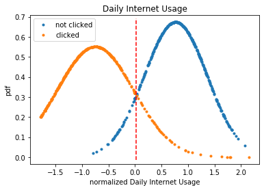

```python
selected = 'Daily Internet Usage'
x0 = unclickedRow[selected]
x1 = clickedRow[selected]
plt.plot(x0,scipy.stats.norm.pdf(x0,mean[selected][0],std[selected][0]),'.',label= 'not clicked')
plt.plot(x1,scipy.stats.norm.pdf(x1,mean[selected][1],std[selected][1]),'.',label = 'clicked')
plt.title(selected)
plt.xlabel('normalized '+selected)
plt.ylabel('pdf')
plt.legend(loc="upper left")
plt.axvline(x=0.025,ymin=0.025, ymax=0.98,color='r',linestyle='--')
```

از شکل پیداست که در نقاط کمتر از 0.025 نمودار نارنجی(کلیک) دارای مقدار بیشتری می باشد و در نقاط بیشتر از آن نمودار آبی(عدم کلیک) مقدار بیشتری می گیرد.بنابراین ستون هایی که مقدار ویژگی Daily Internet Usage(نرمالایز) آن کمتر یا مساوی 0.025 بود در کلاس کلیک کرده و بقیه در کلاس کلیک نکرده قرار می گیرند.

```python
nan_targets = normalized_data[normalized_data['Clicked on Ad'].isnull()].copy()
nan_targets['Clicked on Ad'] = np.where(nan_targets['Daily Internet Usage'] <=0.025,1.0,0.0)
nan_targets = nan_targets[['Clicked on Ad']]
nan_targets
```

|  | Clicked on Ad |
| --- | --- |
| 10 | 1.0 |
| 14 | 1.0 |
| 15 | 1.0 |
| 20 | 0.0 |
| 24 | 1.0 |
| ... | ... |
| 963 | 0.0 |
| 966 | 1.0 |
| 967 | 0.0 |
| 977 | 1.0 |
| 992 | 1.0 |

168 rows × 1 columns

در انتها نیز سطر های پیش بینی شده به همراه اندیس متناظرشان در فایل results.csv ذخیره می شوند.

```python
nan_targets.to_csv('./results.csv')
```

**نتیجه گیری**

در این پروژه یکی از روش های پیش بینی اطلاعات از دست رفته، پیاده سازی شد.برای این کار از نرمال سازی داده ها استفاده شد. برخی داده های موجود در دیتاست خالی بودند به همین جهت تعدادی از روش های پرکردن این داده ها بررسی شدند و به کمک آن داده های از دست رفته پر شدند. سپس به کمک رسم توابع چگالی احتمال آن ها، بهترین ویژگی به عنوان ورودی مدل انتخاب شد.همچنین جهت محاسبات روی داده از vectorization استفاده شد و دیده شد که این روش نسبت به استفاده از حلقه سرعت بیشتری دارد. در انتها نیز به کمک میانگین و واریانس ویژگی انتخاب شده مرزی برای اختصاص کلاس به اطلاعات از دست رفته مشخص شد.